# Modern Data Mining, HW 2

Ben Sra Chongbanyatcharoen

Brandon Kleinman

Philip Situmorang

Due: 11:59 PM, Sunday, 02/13

# Overview

Principle Component Analysis is widely used in data exploration, dimension reduction, data visualization. The aim is to transform original data into uncorrelated linear combinations of the original data while keeping the information contained in the data. High dimensional data tends to show clusters in lower dimensional view.

Clustering Analysis is another form of EDA. Here we are hoping to group data points which are close to each other within the groups and far away between different groups. Clustering using PC’s can be effective. Clustering analysis can be very subjective in the way we need to summarize the properties within each group.

Both PCA and Clustering Analysis are so called unsupervised learning. There is no response variables involved in the process.

For supervised learning, we try to find out how does a set of predictors relate to some response variable of the interest. Multiple regression is still by far, one of the most popular methods. We use linear models as a working model for its simplicity and interpretability. It is important that we use domain knowledge as much as we can to determine the form of the response as well as the function format of the factors.

## 0.1 Objectives

- PCA
- SVD
- Clustering Analysis
- Linear Regression

## 0.2 Review materials

- Study Module 2: PCA
- Study Module 3: Clustering Analysis
- Study Module 4: Multiple regression

## 0.3 Data needed

- `NLSY79.csv`
- `brca_subtype.csv`
- `brca_x_patient.csv`

# 1 Case study 1: Self-seteem

Self-esteem generally describes a person’s overall sense of self-worthiness and personal value. It can play significant role in one’s motivation and success throughout the life. Factors that influence self-esteem can be inner thinking, health condition, age, life experiences etc. We will try to identify possible factors in our data that are related to the level of self-esteem.

In the well-cited National Longitudinal Study of Youth (NLSY79), it follows about 13,000 individuals and numerous individual-year information has been gathered through surveys. The survey data is open to public [here](https://www.nlsinfo.org/investigator/). Among many variables we assembled a subset of variables including personal demographic variables in different years, household environment in 79, ASVAB test Scores in 81 and Self-Esteem scores in 81 and 87 respectively.

The data is store in `NLSY79.csv`.

Here are the description of variables:

**Personal Demographic Variables**

- Gender: a factor with levels “female” and “male”
- Education05: years of education completed by 2005
- HeightFeet05, HeightInch05: height measurement. For example, a person of 5’10 will be recorded as HeightFeet05=5, HeightInch05=10.
- Weight05: weight in lbs.
- Income87, Income05: total annual income from wages and salary in 2005.
- Job87, Job05: job type in 1987 and 2005, including Protective Service Occupations, Food Preparation and Serving Related Occupations, Cleaning and Building Service Occupations, Entertainment Attendants and Related Workers, Funeral Related Occupations, Personal Care and Service Workers, Sales and Related Workers, Office and Administrative Support Workers, Farming, Fishing and Forestry Occupations, Construction Trade and Extraction Workers, Installation, Maintenance and Repairs Workers, Production and Operating Workers, Food Preparation Occupations, Setters, Operators and Tenders, Transportation and Material Moving Workers

**Household Environment**

- Imagazine: a variable taking on the value 1 if anyone in the respondent’s household regularly read magazines in 1979, otherwise 0
- Inewspaper: a variable taking on the value 1 if anyone in the respondent’s household regularly read newspapers in 1979, otherwise 0
- Ilibrary: a variable taking on the value 1 if anyone in the respondent’s household had a library card in 1979, otherwise 0
- MotherEd: mother’s years of education
- FatherEd: father’s years of education
- FamilyIncome78

**Variables Related to ASVAB test Scores in 1981**

| Test | Description |
| --- | --- |
| AFQT | percentile score on the AFQT intelligence test in 1981 |
| Coding | score on the Coding Speed test in 1981 |
| Auto | score on the Automotive and Shop test in 1981 |
| Mechanic | score on the Mechanic test in 1981 |
| Elec | score on the Electronics Information test in 1981 |
| Science | score on the General Science test in 1981 |
| Math | score on the Math test in 1981 |
| Arith | score on the Arithmetic Reasoning test in 1981 |
| Word | score on the Word Knowledge Test in 1981 |
| Parag | score on the Paragraph Comprehension test in 1981 |
| Numer | score on the Numerical Operations test in 1981 |

**Self-Esteem test 81 and 87**

We have two sets of self-esteem test, one in 1981 and the other in 1987. Each set has same 10 questions. They are labeled as `Esteem81` and `Esteem87` respectively followed by the question number. For example, `Esteem81_1` is Esteem question 1 in 81.

The following 10 questions are answered as 1: strongly agree, 2: agree, 3: disagree, 4: strongly disagree

- Esteem 1: “I am a person of worth”
- Esteem 2: “I have a number of good qualities”
- Esteem 3: “I am inclined to feel like a failure”
- Esteem 4: “I do things as well as others”
- Esteem 5: “I do not have much to be proud of”
- Esteem 6: “I take a positive attitude towards myself and others”
- Esteem 7: “I am satisfied with myself”
- Esteem 8: “I wish I could have more respect for myself”
- Esteem 9: “I feel useless at times”
- Esteem 10: “I think I am no good at all”

## 1.1 Data preparation

Load the data. Do a quick EDA to get familiar with the data set. Pay attention to the unit of each variable. Are there any missing values?

```
## [1] 2431   46
```

```
##  [1] "Subject"        "Gender"         "Education05"    "Income87"
##  [5] "Job05"          "Income05"       "Weight05"       "HeightFeet05"
##  [9] "HeightInch05"   "Imagazine"      "Inewspaper"     "Ilibrary"
## [13] "MotherEd"       "FatherEd"       "FamilyIncome78" "Science"
## [17] "Arith"          "Word"           "Parag"          "Number"
## [21] "Coding"         "Auto"           "Math"           "Mechanic"
## [25] "Elec"           "AFQT"           "Esteem81_1"     "Esteem81_2"
## [29] "Esteem81_3"     "Esteem81_4"     "Esteem81_5"     "Esteem81_6"
## [33] "Esteem81_7"     "Esteem81_8"     "Esteem81_9"     "Esteem81_10"
## [37] "Esteem87_1"     "Esteem87_2"     "Esteem87_3"     "Esteem87_4"
## [41] "Esteem87_5"     "Esteem87_6"     "Esteem87_7"     "Esteem87_8"
## [45] "Esteem87_9"     "Esteem87_10"
```

```
## [1] 0
```

## 1.2 1.2 Self esteem evalution

Let’s concentrate on Esteem scores evaluated in 87.

1. Reverse Esteem 1, 2, 4, 6, and 7 so that a higher score corresponds to higher self-esteem. (Hint: if we store the esteem data in `data.esteem`, then `data.esteem[, c(1, 2, 4, 6, 7)] <- 5 - data.esteem[, c(1, 2, 4, 6, 7)]` to reverse the score.)

[output not shown]

2. Write a brief summary with necessary plots about the 10 esteem measurements.

### 1.2.1 ANSWER

Summary:

- The average of each esteem score is close to 3.5, except for those of Esteem 8 and 9, which are closer to 3 as shown in the table and distribution histogram below.
- The standard deviation of each esteem score is about 0.5, except for those of Esteem 8, 9 and 10, which are closer to 0.7, as shown in the table below.

| variable | mean | sd |
| --- | --- | --- |
| Esteem87_1 | 3.62 | 0.499 |
| Esteem87_2 | 3.60 | 0.501 |
| Esteem87_3 | 3.58 | 0.542 |
| Esteem87_4 | 3.50 | 0.533 |
| Esteem87_5 | 3.53 | 0.600 |
| Esteem87_6 | 3.41 | 0.562 |
| Esteem87_7 | 3.28 | 0.582 |
| Esteem87_8 | 3.10 | 0.738 |
| Esteem87_9 | 3.06 | 0.740 |
| Esteem87_10 | 3.37 | 0.653 |

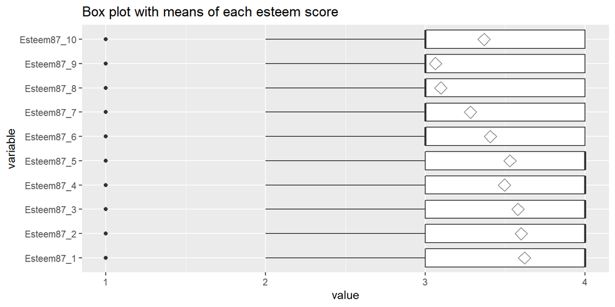

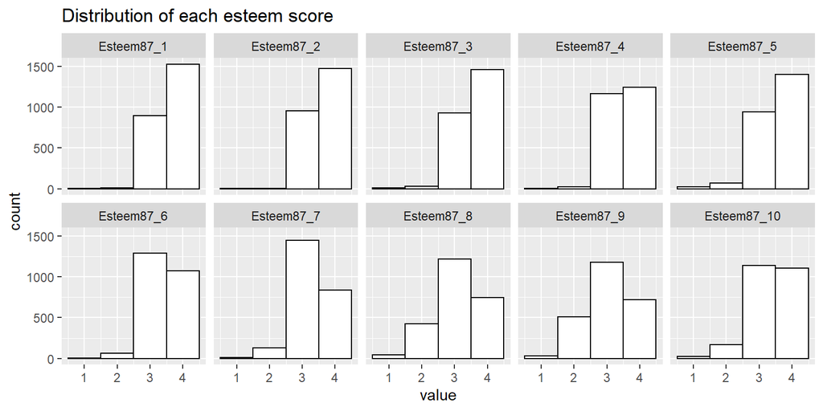

3. Do esteem scores all positively correlated? Report the pairwise correlation table and write a brief summary.

### 1.2.2 ANSWER

Summary:

- We can see positive correlation among all extreme scores, however, the degree of correlation varies from 0.24 to 0.7 , as detailed in the pairwise correlation table below.
- Notably, the scores for Esteem 1 (“I am a person of worth”) and Esteem 2 (“I have a number of good qualities”) are strongly correlated, with a correlation coefficient of 0.7.

|  | Esteem87_1 | Esteem87_2 | Esteem87_3 | Esteem87_4 | Esteem87_5 | Esteem87_6 | Esteem87_7 | Esteem87_8 | Esteem87_9 | Esteem87_10 |
| --- | --- | --- | --- | --- | --- | --- | --- | --- | --- | --- |
| Esteem87_1 | 1.00 | 0.70 | 0.45 | 0.53 | 0.40 | 0.46 | 0.38 | 0.27 | 0.24 | 0.31 |
| Esteem87_2 | 0.70 | 1.00 | 0.44 | 0.55 | 0.40 | 0.48 | 0.41 | 0.28 | 0.26 | 0.33 |
| Esteem87_3 | 0.45 | 0.44 | 1.00 | 0.41 | 0.55 | 0.41 | 0.34 | 0.35 | 0.35 | 0.46 |
| Esteem87_4 | 0.53 | 0.55 | 0.41 | 1.00 | 0.38 | 0.51 | 0.42 | 0.30 | 0.29 | 0.37 |
| Esteem87_5 | 0.40 | 0.40 | 0.55 | 0.38 | 1.00 | 0.40 | 0.37 | 0.38 | 0.35 | 0.44 |
| Esteem87_6 | 0.46 | 0.48 | 0.41 | 0.51 | 0.40 | 1.00 | 0.60 | 0.41 | 0.36 | 0.44 |
| Esteem87_7 | 0.38 | 0.41 | 0.34 | 0.42 | 0.37 | 0.60 | 1.00 | 0.39 | 0.35 | 0.39 |
| Esteem87_8 | 0.27 | 0.28 | 0.35 | 0.30 | 0.38 | 0.41 | 0.39 | 1.00 | 0.43 | 0.44 |
| Esteem87_9 | 0.24 | 0.26 | 0.35 | 0.29 | 0.35 | 0.36 | 0.35 | 0.43 | 1.00 | 0.58 |
| Esteem87_10 | 0.31 | 0.33 | 0.46 | 0.37 | 0.44 | 0.44 | 0.39 | 0.44 | 0.58 | 1.00 |

4. PCA on 10 esteem measurements. (centered but no scaling)
   1. Report the PC1 and PC2 loadings. Are they unit vectors? Are they orthogonal?

### 1.2.3 ANSWER

The value of PC1 and PC2 can be found in the table below:

```
## [1] "sdev"     "rotation" "center"   "scale"    "x"
```

|  | PC1 | PC2 |
| --- | --- | --- |
| Esteem87_1 | 0.235 | -0.374 |
| Esteem87_2 | 0.244 | -0.367 |
| Esteem87_3 | 0.279 | -0.149 |
| Esteem87_4 | 0.261 | -0.321 |
| Esteem87_5 | 0.312 | -0.131 |
| Esteem87_6 | 0.313 | -0.209 |
| Esteem87_7 | 0.299 | -0.163 |
| Esteem87_8 | 0.393 | 0.332 |
| Esteem87_9 | 0.398 | 0.578 |
| Esteem87_10 | 0.376 | 0.260 |

PC1 and PC2 are orthogonal, due to the nature of how PCs are calculated.

```
##  PC1  PC2  PC3  PC4  PC5  PC6  PC7  PC8  PC9 PC10
##    1    1    1    1    1    1    1    1    1    1
```

```
b) Are there good interpretations for PC1 and PC2? (If loadings are all negative, take the positive loadings for the ease of interpretation)
```

### 1.2.4 ANSWER

Interpretation:

- **PC1**: since all 10 loadings are positive are all positive and are roughly around 0.3, we can interpret that PC1 is proportional to the total of all esteem scores A higher PC1 represents a higher total score overall. Although it should be noted that the scores for Esteem 8,9,10 affects the value of PC1 more than others due to their relatively higher loadings.
- **PC2**: since the loadings of Esteem 8,9, and 10 are positive while the loadings of other Esteem scores are negative, roughly speaking, PC2 represents how much the scores for Esteem 8, 9, and 10 are higher compared to other scores. However, since all questions (Esteem 1 to 10) are all asking about similar things, it is difficult to interpret the meaning of PC2.
  3. How is the PC1 score obtained for each subject? Write down the formula.

### 1.2.5 ANSWER

PC1 = 0.235(Esteem87_1) + 0.244(Essteem87_2) + 0.279(Esteem87_3) + 0.261(Esteem87_4) + 0.312(Esteem87_5) + 0.313(Esteem87_6) + 0.299(Esteem87_7) + 0.393(Esteem87_8) + 0.398(Esteem87_9) + 0.376(Esteem87_10)

```
d) Are PC1 scores and PC2 scores in the data uncorrelated?
```

### 1.2.6 ANSWER

PC1 and PC2 scores are uncorrelated.

```
##     PC1 PC2
## PC1   1   0
## PC2   0   1
```

```
e) Plot PVE (Proportion of Variance Explained) and summarize the plot.
```

### 1.2.7 ANSWER

Below is the table summary of the plots (PVE). PC1 explains 46.6% of the variance, PC2 explains 12.71% of the variance, and so on.

```
##        PC Proportion_of_Variance Cumulative_Proportion
## PC1   PC1                 0.4661                 0.466
## PC2   PC2                 0.1271                 0.593
## PC3   PC3                 0.0905                 0.684
## PC4   PC4                 0.0750                 0.759
## PC5   PC5                 0.0588                 0.818
## PC6   PC6                 0.0519                 0.869
## PC7   PC7                 0.0390                 0.908
## PC8   PC8                 0.0373                 0.946
## PC9   PC9                 0.0339                 0.980
## PC10 PC10                 0.0204                 1.000
```

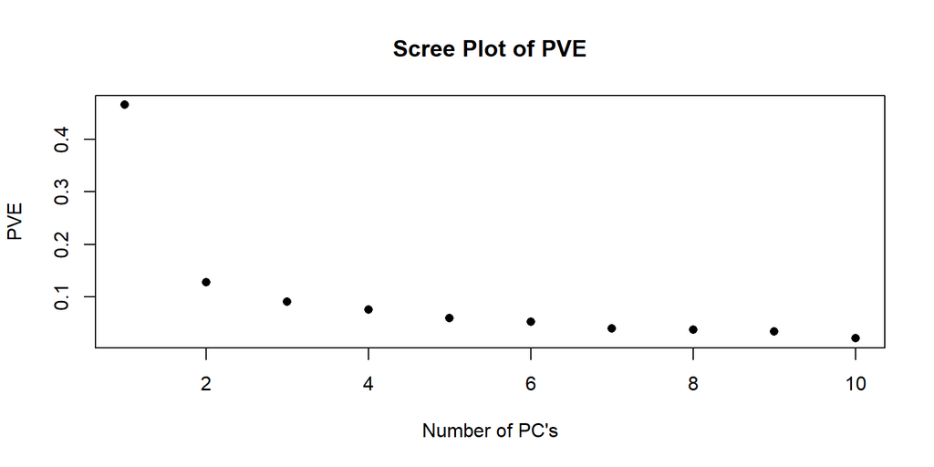

f) Also plot CPVE (Cumulative Proportion of Variance Explained). What proportion of the variance in the data is explained by the first two principal components?

```
### ANSWER
```

The first two principal components explain 59.3% if the variance in the data.

|  | PC | Cumulative_Proportion |
| --- | --- | --- |
| PC1 | PC1 | 0.466 |
| PC2 | PC2 | 0.593 |

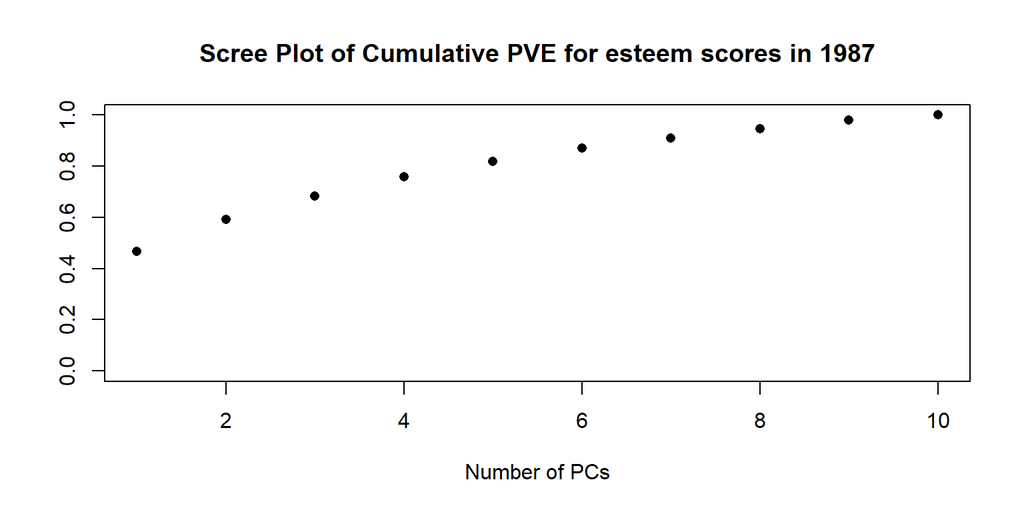

```
g) PC’s provide us with a low dimensional view of the self-esteem scores. Use a biplot with the first two PC's to display the data.  Give an interpretation of PC1 and PC2 from the plot. (try `ggbiplot` if you could, much prettier!)

### ANSWER
```

The biplot indicates that:

- PC1 loadings have the same signs, although the magnitude varies depending on the esteem score
- PC2 captures the different between esteeem score 8, 9, 10 and others.
- Esteem scores 8, 9, and 10 are correlated, and other esteem scores are correlated among themselves

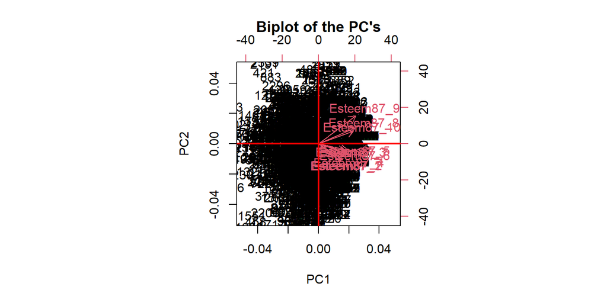

5. Apply k-means to cluster subjects on the original esteem scores
   1. Find a reasonable number of clusters using within sum of squared with elbow rules.

### 1.2.8 ANSWER

Using the elbow rule, we decided to use k=2 to have two clusters.

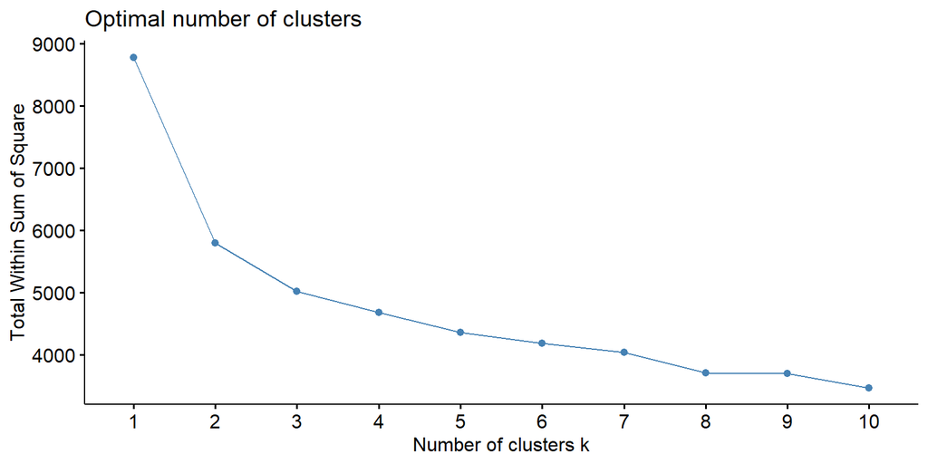

```
b) Can you summarize common features within each cluster?
```

### 1.2.9 ANSWER

From the summary of each group’s characteristics, we can see that, compared to group 2, group 1:

- scores higher across all esteem scores
- is from a family with parents who had more education and higher income
- has a higher AFQT score

Please refer to the code below regarding our process in conducting K-means clustering and summarizing the data of each group.

```
## [1] 2431   37
```

```
## [1] 0
```

| group | 1 | 2 |
| --- | --- | --- |
| Avg_Education05 | 14.4 | 13.4 |
| Avg_Income87 | 15139 | 11792 |
| Avg_Income05 | 59109 | 40464 |
| Avg_MotherEd | 12.1 | 11.4 |
| Avg_FatherEd | 12.3 | 11.4 |
| Avg_FamilyIncome78 | 22677 | 19936 |
| Avg_AFQT | 60.6 | 49.2 |
| Avg_Esteem87_1 | 3.89 | 3.37 |
| Avg_Esteem87_2 | 3.89 | 3.33 |
| Avg_Esteem87_3 | 3.90 | 3.28 |
| Avg_Esteem87_4 | 3.82 | 3.20 |
| Avg_Esteem87_5 | 3.90 | 3.18 |
| Avg_Esteem87_6 | 3.78 | 3.06 |
| Avg_Esteem87_7 | 3.63 | 2.96 |
| Avg_Esteem87_8 | 3.53 | 2.70 |
| Avg_Esteem87_9 | 3.49 | 2.67 |
| Avg_Esteem87_10 | 3.80 | 2.97 |

[output not shown]

Please refer to the code below regarding our process in conducting K-means clustering and summarizing the data of each group.

```
## [1] 2431   37
```

```
## [1] 0
```

| group | 1 | 2 |
| --- | --- | --- |
| Avg_Education05 | 13.4 | 14.4 |
| Avg_Income87 | 11792 | 15139 |
| Avg_Income05 | 40464 | 59109 |
| Avg_MotherEd | 11.4 | 12.1 |
| Avg_FatherEd | 11.4 | 12.3 |
| Avg_FamilyIncome78 | 19936 | 22677 |
| Avg_AFQT | 49.2 | 60.6 |
| Avg_Esteem87_1 | 3.37 | 3.89 |
| Avg_Esteem87_2 | 3.33 | 3.89 |
| Avg_Esteem87_3 | 3.28 | 3.90 |
| Avg_Esteem87_4 | 3.20 | 3.82 |
| Avg_Esteem87_5 | 3.18 | 3.90 |
| Avg_Esteem87_6 | 3.06 | 3.78 |
| Avg_Esteem87_7 | 2.96 | 3.63 |
| Avg_Esteem87_8 | 2.70 | 3.53 |
| Avg_Esteem87_9 | 2.67 | 3.49 |
| Avg_Esteem87_10 | 2.97 | 3.80 |

```
c) Can you visualize the clusters with somewhat clear boundaries? You may try different pairs of variables and different PC pairs of the esteem scores.
```

### 1.2.11 ANSWER

We have found that PC1 and AFQT are able to produce clear boundaries for each cluster. PC1 clearly separates cluster 1 from cluster 2, while we can see that the average AFQT for group 2 is higher than group 1’s.

We have also left plots with different pairs of variables as reference.

*Reference: We used to code below to prepare the data*

```
## [1] 2431   39
```

```
## [1] 0
```

The plots are below:

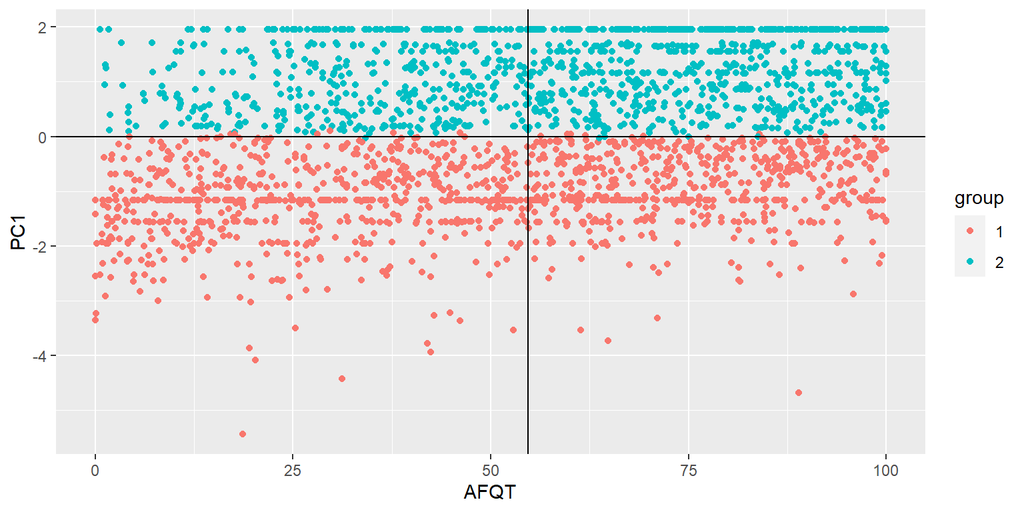

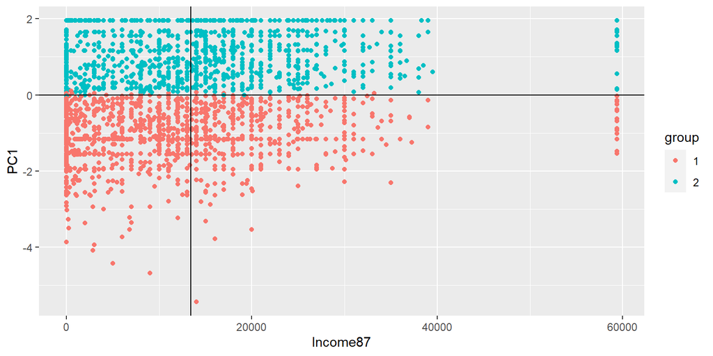

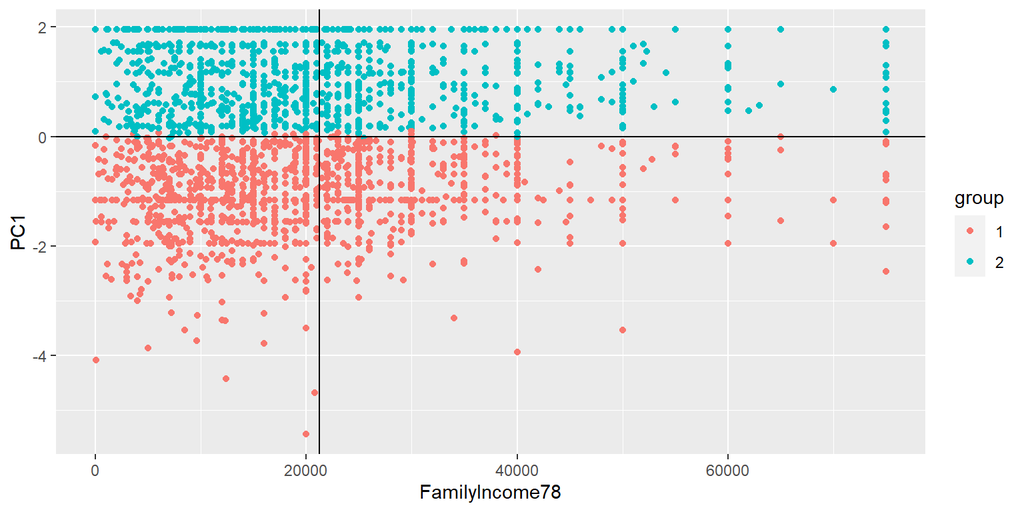

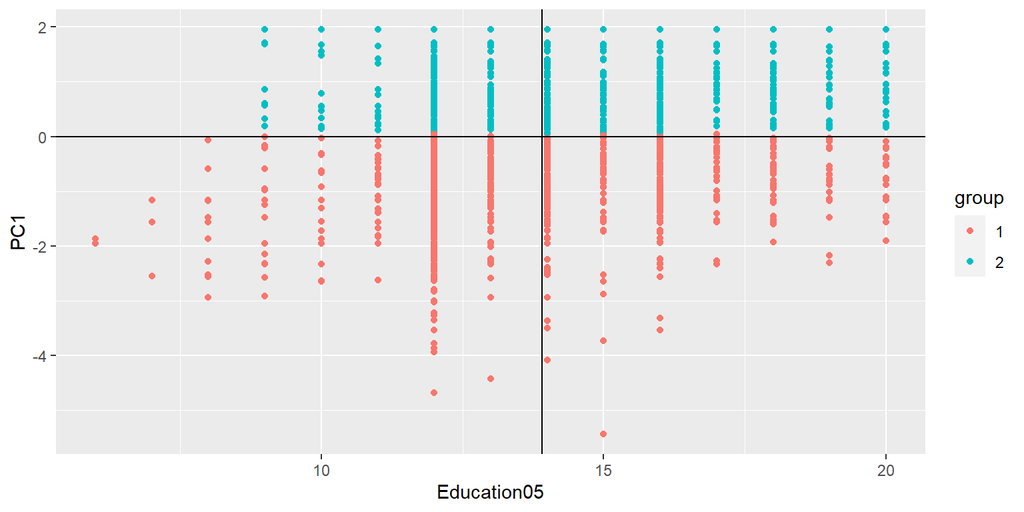

6. We now try to find out what factors are related to self-esteem? PC1 of all the Esteem scores is a good variable to summarize one’s esteem scores. We take PC1 as our response variable.
   1. Prepare possible factors/variables:
- Personal information: gender, education (05, problematic), log(income) in 87, job type in 87, Body mass index as a measure of health (The BMI is defined as the body mass divided by the square of the body height, and is universally expressed in units of kg/m²). Since BMI is measured in 05, this will not be a good practice to be inclueded as possible variables.

### 1.2.12 ANSWER

- Household environment: Imagazine, Inewspaper, Ilibrary, MotherEd, FatherEd, FamilyIncome78. Do set indicators `Imagazine` and `Ilibrary` as factors

###ANSWER

- Use PC1 of SVABS as level of intelligence

###ANSWER

```
## [1] "sdev"     "rotation" "center"   "scale"    "x"
```

|  | x |
| --- | --- |
| Science | 0.328 |
| Arith | 0.336 |
| Word | 0.330 |
| Parag | 0.310 |
| Number | 0.255 |
| Coding | 0.217 |
| Auto | 0.247 |
| Math | 0.322 |
| Mechanic | 0.291 |
| Elec | 0.297 |
| AFQT | 0.353 |

We can see from the loadings of PC1 that all loadings have the same sign and have values around 0.3. We can interpret that PC1 represents the sum of all scores: higher PC1 represents a higher sum of all scores.

We will next look at the scree plot of cumulative PVE for PCs of ASVAB test scores

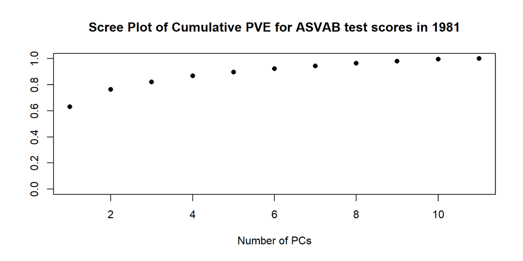

We can see from the Scree Plot that PC1 alone accounts for over 60% of the variance in ASVAB test scores.

Next, we will use the code below to add PC1 of ASVAB test scores to the data for analysis

```
## [1] 2431   13
```

```
## [1] 0
```

```
##  [1] "Subject"        "Gender"         "Imagazine"      "Inewspaper"
##  [5] "Ilibrary"       "MotherEd"       "FatherEd"       "FamilyIncome78"
##  [9] "group"          "PC1_esteem"     "PC2_esteem"     "log_Income87"
## [13] "PC1_ASVAB"
```

2. Run a few regression models between PC1 of all the esteem scores and factors listed in a). Find a final best model with your own criterion.

### 1.2.13 ANSWER

- the model must pass F-test at 95% confidence interval, and the explanatory variables must pass the t test at 95% confidence interval
- must uphold the three assumptions of OLS (linearity, normality, homoscedasticity)
- small prediction errors (RSE)

- How did you land this model? Run a model diagnosis to see if the linear model assumptions are reasonably met.

###ANSWER

Write a summary of your findings. In particular, explain what and how the variables in the model affect one’s self-esteem.

###ANSWER

# 2 Case study 2: Breast cancer sub-type

[The Cancer Genome Atlas (TCGA)](https://www.cancer.gov/about-nci/organization/ccg/research/structural-genomics/tcga), a landmark cancer genomics program by National Cancer Institute (NCI), molecularly characterized over 20,000 primary cancer and matched normal samples spanning 33 cancer types. The genome data is open to public from the [Genomic Data Commons Data Portal (GDC)](https://portal.gdc.cancer.gov/).

In this study, we focus on 4 sub-types of breast cancer (BRCA): basal-like (basal), Luminal A-like (lumA), Luminal B-like (lumB), HER2-enriched. The sub-type is based on PAM50, a clinical-grade luminal-basal classifier.

- Luminal A cancers are low-grade, tend to grow slowly and have the best prognosis.
- Luminal B cancers generally grow slightly faster than luminal A cancers and their prognosis is slightly worse.
- HER2-enriched cancers tend to grow faster than luminal cancers and can have a worse prognosis, but they are often successfully treated with targeted therapies aimed at the HER2 protein.
- Basal-like breast cancers or triple negative breast cancers do not have the three receptors that the other sub-types have so have fewer treatment options.

We will try to use mRNA expression data alone without the labels to classify 4 sub-types. Classification without labels or prediction without outcomes is called unsupervised learning. We will use K-means and spectrum clustering to cluster the mRNA data and see whether the sub-type can be separated through mRNA data.

We first read the data using `data.table::fread()` which is a faster way to read in big data than `read.csv()`.

1. Summary and transformation
   1. How many patients are there in each sub-type?

**ANSWER:** 208 in Basal, 91 in Her2, 628 in lumA, 233 in lumB.

```
##   Group.1   x
## 1   Basal 208
## 2    Her2  91
## 3    LumA 628
## 4    LumB 233
```

```
b) Randomly pick 5 genes and plot the histogram by each sub-type.
```

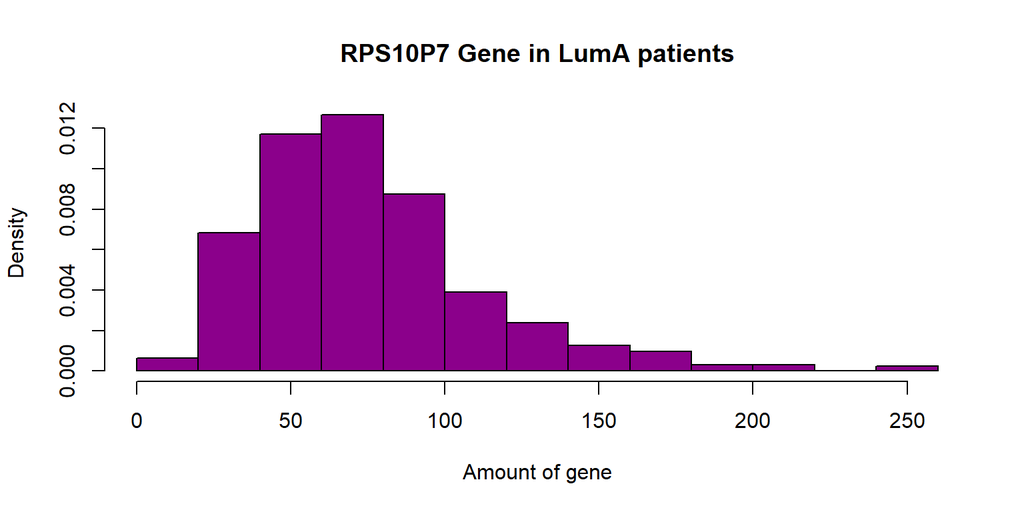

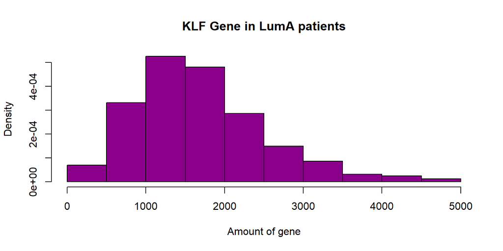

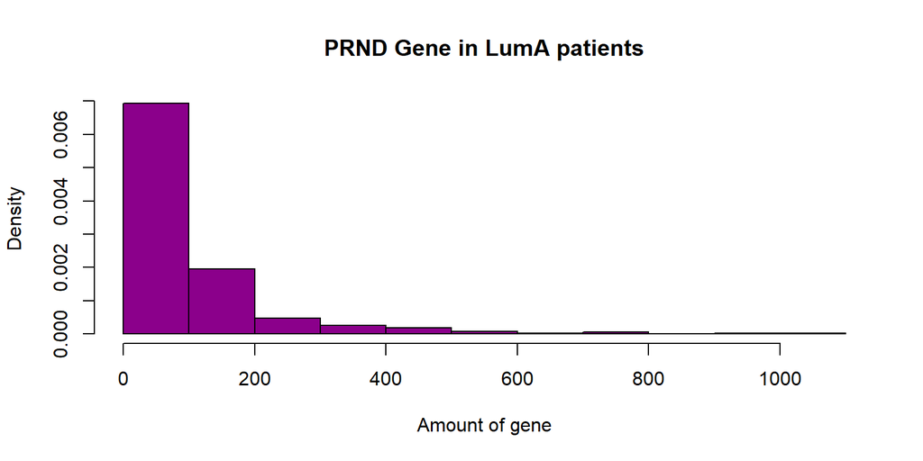

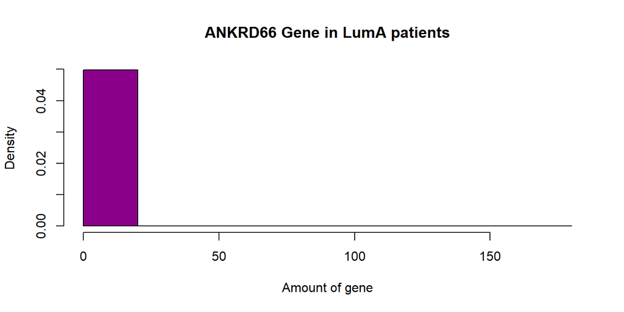

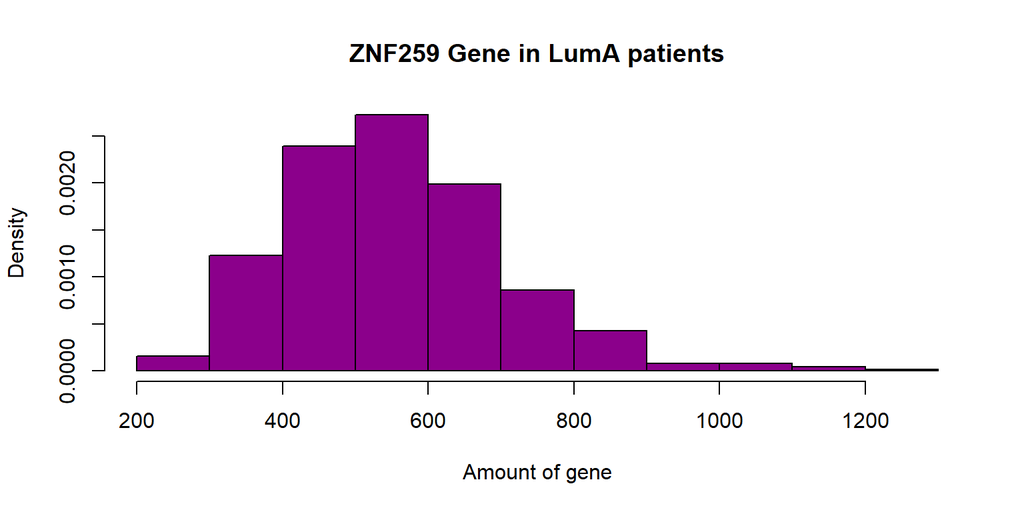

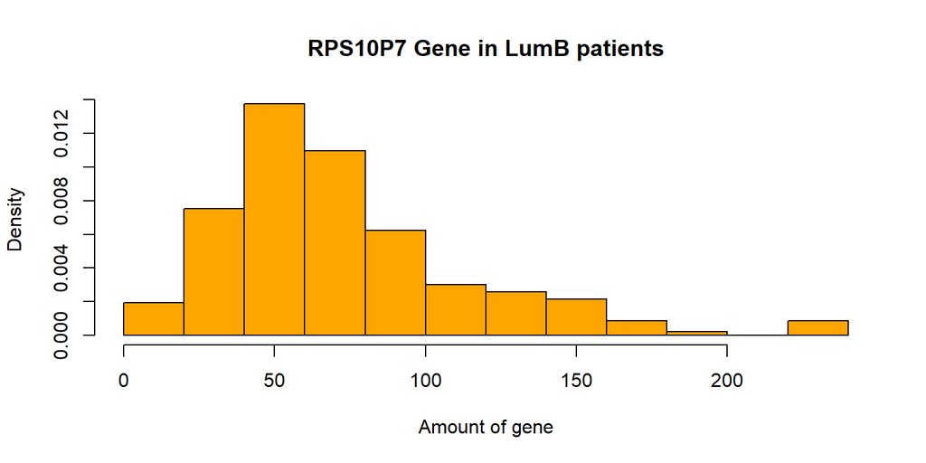

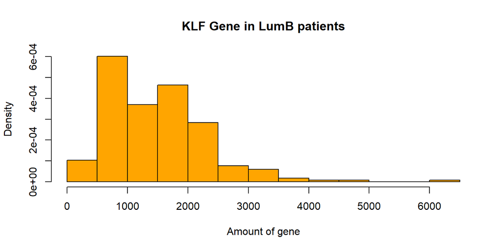

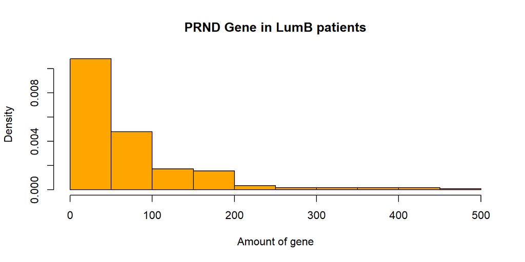

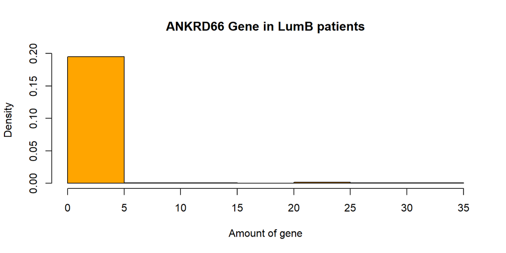

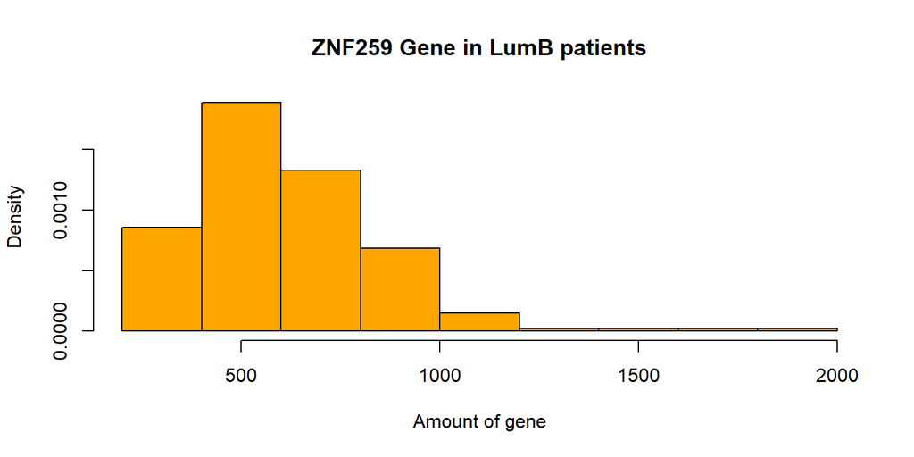

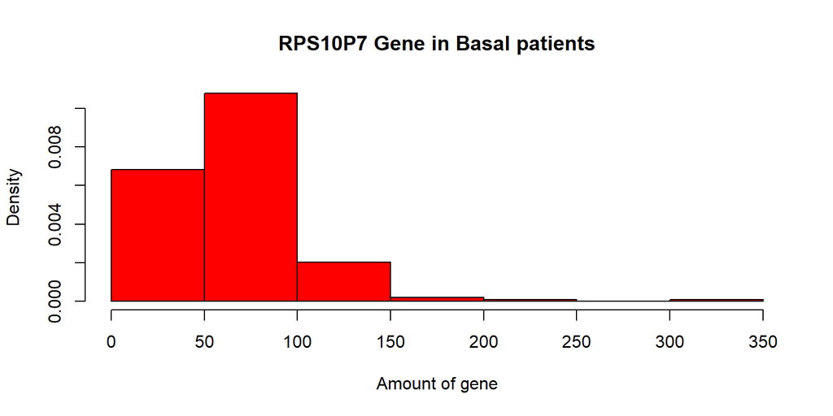

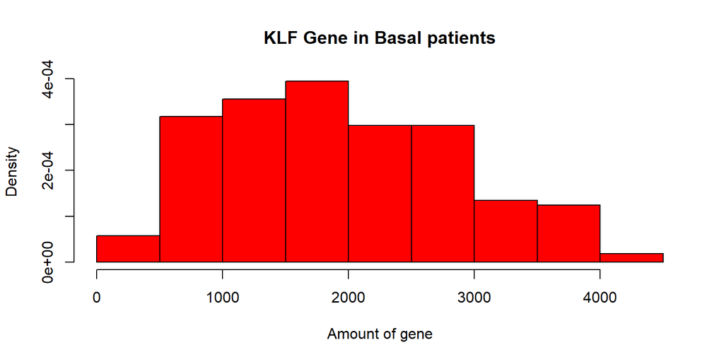

[8 more figures not shown]

c) Remove gene with zero count and no variability. Then apply logarithmic transform.

2. Apply kmeans on the transformed dataset with 4 centers and output the discrepancy table between the real sub-type `brca_subtype` and the cluster labels.

```
##
## brca_subtype   1   2   3   4
##        Basal   0  18   0 190
##        Her2   42  21   0  28
##        LumA  276 350   1   1
##        LumB  182  48   1   2
```

3. Spectrum clustering: to scale or not to scale?
   1. Apply PCA on the centered and scaled dataset. How many PCs should we use and why? You are encouraged to use `irlba::irlba()`.

**ANSWER:** We should use 4 principal components by the elbow rule.

```
## [1] "d"     "u"     "v"     "iter"  "mprod"
```

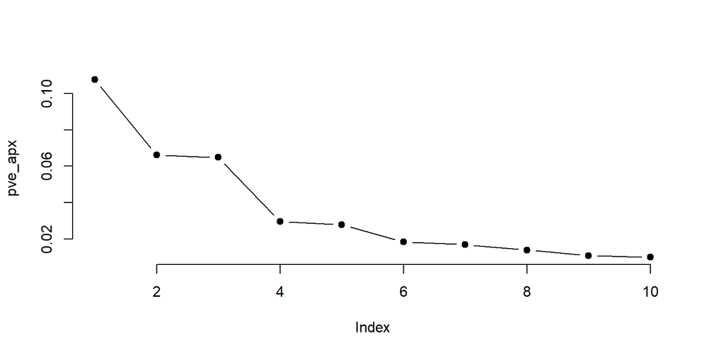

[output not shown]

**ANSWER:** We should scale for clustering purposes. Some genes measure in the thousands and while others in hundreds or less, and by scaling we ensure that we are measuring euclidean distance relative to the measurements within each gene.

**Centered and Scaled**

**Centered and unscaled**

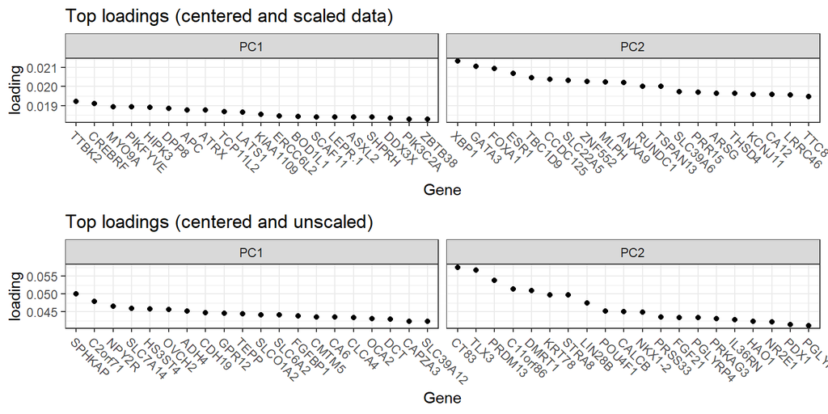

4. Spectrum clustering: center but do not scale the data
   1. Use the first 4 PCs of the centered and unscaled data and apply kmeans. Find a reasonable number of clusters using within sum of squared with the elbow rule.

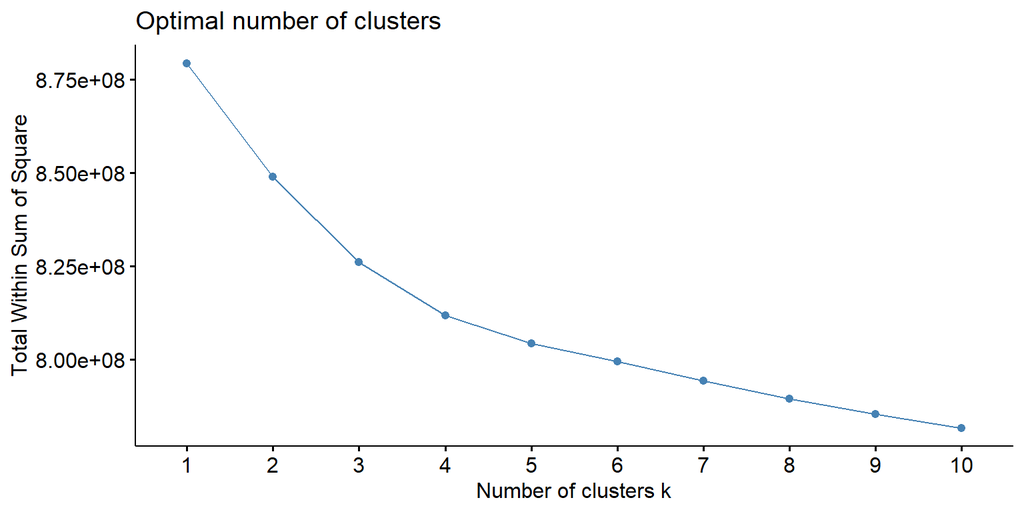

[output not shown]

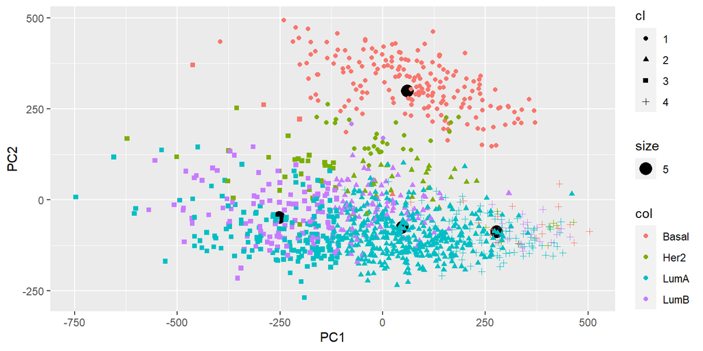

```
c) Compare the clustering result from applying kmeans to the original data and the clustering result from applying kmeans to 4 PCs. Does PCA help in kmeans clustering? What might be the reasons if PCA helps?
```

```
##
## brca_subtype   1   2   3   4
##        Basal   0  18   0 190
##        Her2   42  21   0  28
##        LumA  276 350   1   1
##        LumB  182  48   1   2
```

```
##
## brca_subtype   1   2   3   4
##        Basal 187   1   3  17
##        Her2   28  27  27   9
##        LumA    0 376 161  91
##        LumB    2  99 110  22
```

[output not shown]

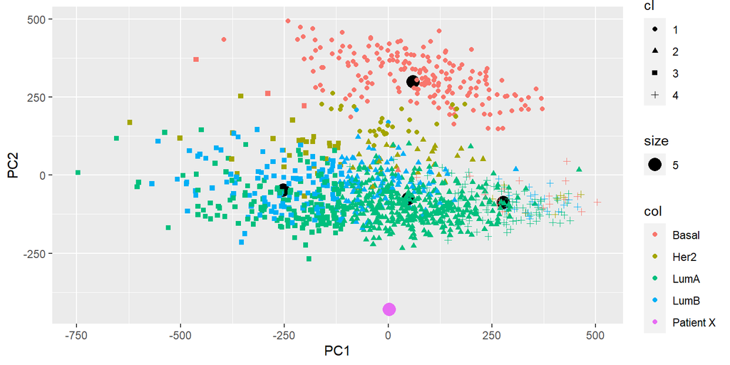

# 3 Case study 3: Auto data set

Get familiar with this dataset first. Tip: you can use the command `?ISLR::Auto` to view a description of the dataset.

## 3.1 EDA

Explore the data, with particular focus on pairwise plots and summary statistics. Briefly summarize your findings and any peculiarities in the data.

[output not shown]

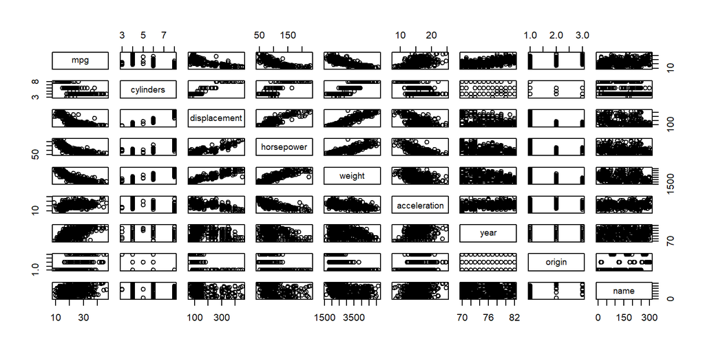

```
##       mpg         cylinders     displacement   horsepower        weight
##  Min.   : 9.0   Min.   :3.00   Min.   : 68   Min.   : 46.0   Min.   :1613
##  1st Qu.:17.0   1st Qu.:4.00   1st Qu.:105   1st Qu.: 75.0   1st Qu.:2225
##  Median :22.8   Median :4.00   Median :151   Median : 93.5   Median :2804
##  Mean   :23.4   Mean   :5.47   Mean   :194   Mean   :104.5   Mean   :2978
##  3rd Qu.:29.0   3rd Qu.:8.00   3rd Qu.:276   3rd Qu.:126.0   3rd Qu.:3615
##  Max.   :46.6   Max.   :8.00   Max.   :455   Max.   :230.0   Max.   :5140
##
##   acceleration       year        origin                     name
##  Min.   : 8.0   Min.   :70   Min.   :1.00   amc matador       :  5
##  1st Qu.:13.8   1st Qu.:73   1st Qu.:1.00   ford pinto        :  5
##  Median :15.5   Median :76   Median :1.00   toyota corolla    :  5
##  Mean   :15.5   Mean   :76   Mean   :1.58   amc gremlin       :  4
##  3rd Qu.:17.0   3rd Qu.:79   3rd Qu.:2.00   amc hornet        :  4
##  Max.   :24.8   Max.   :82   Max.   :3.00   chevrolet chevette:  4
##                                             (Other)           :365
```

Japanese and European cars seem to be lighter and have lower horsepower,on average, when compared to their American counterparts. Displacement, horsepower, and weight all seem to be positively correlated. Cars with four cylinders seem to have higher MPG, on average, than cars with six and eight cylinders. Displacement, horsepower, and weight seem to be negatively correlated with MPG.

## 3.2 What effect does `time` have on `MPG`?

1. Start with a simple regression of `mpg` vs. `year` and report R’s `summary` output. Is `year` a significant variable at the .05 level? State what effect `year` has on `mpg`, if any, according to this model.

```
##
## Call:
## lm(formula = mpg ~ year, data = Auto)
##
## Residuals:
##     Min      1Q  Median      3Q     Max
## -12.021  -5.441  -0.441   4.974  18.209
##
## Coefficients:
##             Estimate Std. Error t value Pr(>|t|)
## (Intercept) -70.0117     6.6452   -10.5   <2e-16 ***
## year          1.2300     0.0874    14.1   <2e-16 ***
## ---
## Signif. codes:  0 '***' 0.001 '**' 0.01 '*' 0.05 '.' 0.1 ' ' 1
##
## Residual standard error: 6.36 on 390 degrees of freedom
## Multiple R-squared:  0.337,  Adjusted R-squared:  0.335
## F-statistic:  198 on 1 and 390 DF,  p-value: <2e-16
```

The hypothesis test which has H_0: year = 0 H_A: year != 0 has a p-value of approximately 0. We can confidently reject the null hypothesis and state that year is significant at the level of 0.05. The coefficient of year is 1.23 which means that every subsequent year a car is produced the MPG of cars produced that year increases by an average of 1.23.

2. Add `horsepower` on top of the variable `year` to your linear model. Is `year` still a significant variable at the .05 level? Give a precise interpretation of the `year`’s effect found here.

```
##
## Call:
## lm(formula = mpg ~ year + horsepower, data = Auto)
##
## Residuals:
##     Min      1Q  Median      3Q     Max
## -12.077  -3.078  -0.431   2.588  15.315
##
## Coefficients:
##              Estimate Std. Error t value Pr(>|t|)
## (Intercept) -12.73917    5.34903   -2.38    0.018 *
## year          0.65727    0.06626    9.92   <2e-16 ***
## horsepower   -0.13165    0.00634  -20.76   <2e-16 ***
## ---
## Signif. codes:  0 '***' 0.001 '**' 0.01 '*' 0.05 '.' 0.1 ' ' 1
##
## Residual standard error: 4.39 on 389 degrees of freedom
## Multiple R-squared:  0.685,  Adjusted R-squared:  0.684
## F-statistic:  424 on 2 and 389 DF,  p-value: <2e-16
```

The P-value of the hypothesis test is still under the level of 0.05 so we can confidently say that year is a significant variable. The coefficient has changed to 0.65727 which means that every subsequent year a car is produced the MPG of cars produced that year increases by an average of 0.65727.

3. The two 95% CI’s for the coefficient of year differ among (i) and (ii). How would you explain the difference to a non-statistician?

```
## [1] 1.06 1.40
```

```
## [1] 0.525 0.790
```

The 95% confidence interval for year according to the model created in part i is [1.06,1.40]. The meaning of this is that we are 95% confident in saying that every subsequent year a car is produced, the MPG of cars produced that year increases by a value in the range of [1.06,1.40]. The 95% confidence interval for year according to the model created in part ii is [0.525,0.790]. The meaning of this is that we are 95% confident in saying that every subsequent year a car is produced, the MPG of cars produced that year increases by a value in the range of [0.525,0.790].

4. Create a model with interaction by fitting `lm(mpg ~ year * horsepower)`. Is the interaction effect significant at .05 level? Explain the year effect (if any).

```
##
## Call:
## lm(formula = mpg ~ year * horsepower, data = Auto)
##
## Residuals:
##     Min      1Q  Median      3Q     Max
## -12.349  -2.451  -0.456   2.406  14.444
##
## Coefficients:
##                  Estimate Std. Error t value Pr(>|t|)
## (Intercept)     -1.27e+02   1.21e+01  -10.45   <2e-16 ***
## year             2.19e+00   1.61e-01   13.59   <2e-16 ***
## horsepower       1.05e+00   1.15e-01    9.06   <2e-16 ***
## year:horsepower -1.60e-02   1.56e-03  -10.22   <2e-16 ***
## ---
## Signif. codes:  0 '***' 0.001 '**' 0.01 '*' 0.05 '.' 0.1 ' ' 1
##
## Residual standard error: 3.9 on 388 degrees of freedom
## Multiple R-squared:  0.752,  Adjusted R-squared:  0.75
## F-statistic:  393 on 3 and 388 DF,  p-value: <2e-16
```

The interaction effect is significant at the 0.05 level, the P-values of the F test is well below the significance threshold. When we multiply independent variables together in regression we lose our ability to make interpretations of coefficients.

## 3.3 Categorical predictors

Remember that the same variable can play different roles! Take a quick look at the variable `cylinders`, and try to use this variable in the following analyses wisely. We all agree that a larger number of cylinders will lower mpg. However, we can interpret `cylinders` as either a continuous (numeric) variable or a categorical variable.

1. Fit a model that treats `cylinders` as a continuous/numeric variable. Is `cylinders` significant at the 0.01 level? What effect does `cylinders` play in this model?

```
##
## Call:
## lm(formula = mpg ~ cylinders, data = Auto)
##
## Residuals:
##     Min      1Q  Median      3Q     Max
## -14.241  -3.183  -0.633   2.549  17.917
##
## Coefficients:
##             Estimate Std. Error t value Pr(>|t|)
## (Intercept)   42.916      0.835    51.4   <2e-16 ***
## cylinders     -3.558      0.146   -24.4   <2e-16 ***
## ---
## Signif. codes:  0 '***' 0.001 '**' 0.01 '*' 0.05 '.' 0.1 ' ' 1
##
## Residual standard error: 4.91 on 390 degrees of freedom
## Multiple R-squared:  0.605,  Adjusted R-squared:  0.604
## F-statistic:  597 on 1 and 390 DF,  p-value: <2e-16
```

The coefficient of cylinders is -3.558. This means that for every additional cylinder added to the engine block to car, on average, loses 3.558 units of MPG.

2. Fit a model that treats `cylinders` as a categorical/factor. Is `cylinders` significant at the .01 level? What is the effect of `cylinders` in this model? Describe the `cylinders` effect over `mpg`.

```
##
## Call:
## lm(formula = mpg ~ factor(cylinders), data = Auto)
##
## Residuals:
##     Min      1Q  Median      3Q     Max
## -11.284  -2.904  -0.963   2.344  18.027
##
## Coefficients:
##                    Estimate Std. Error t value Pr(>|t|)
## (Intercept)          20.550      2.349    8.75  < 2e-16 ***
## factor(cylinders)4    8.734      2.373    3.68  0.00027 ***
## factor(cylinders)5    6.817      3.589    1.90  0.05825 .
## factor(cylinders)6   -0.577      2.405   -0.24  0.81071
## factor(cylinders)8   -5.587      2.395   -2.33  0.02015 *
## ---
## Signif. codes:  0 '***' 0.001 '**' 0.01 '*' 0.05 '.' 0.1 ' ' 1
##
## Residual standard error: 4.7 on 387 degrees of freedom
## Multiple R-squared:  0.641,  Adjusted R-squared:  0.638
## F-statistic:  173 on 4 and 387 DF,  p-value: <2e-16
```

The reference level for cylinders in this regression is 3. This means that all of the coefficients are compared to the base case, which is when there are three cylinders. The coefficient for 4 cylinders is 8.734. The interpretation of this is that compared to a car with 3 cylinders, cars with 4 cylinders have – on average – 8.734 more MPG. The same logic is extended to all cylinders in the dataset. Only the 4 cylinders inntercept is significant at the 0.01 significance level.

3. What are the fundamental differences between treating `cylinders` as a continuous and categorical variable in your models?

The fundamental difference between treating a variable as continuous versus categorical is that coefficients for continuous variables are interpreted as describing the average change in the dependent variable when the independent variable is increased by one unit. Coefficients for categorical variables are interpreted as describing the average change when the variable is changed from the reference level to the level of the coefficient (changing from 3 to 4 cylinders in the example above).

4. Can you test the null hypothesis: fit0: `mpg` is linear in `cylinders` vs. fit1: `mpg` relates to `cylinders` as a categorical variable at .01 level?

```
##
## Call:
## lm(formula = mpg ~ cylinders, data = Auto)
##
## Residuals:
##     Min      1Q  Median      3Q     Max
## -14.241  -3.183  -0.633   2.549  17.917
##
## Coefficients:
##             Estimate Std. Error t value Pr(>|t|)
## (Intercept)   42.916      0.835    51.4   <2e-16 ***
## cylinders     -3.558      0.146   -24.4   <2e-16 ***
## ---
## Signif. codes:  0 '***' 0.001 '**' 0.01 '*' 0.05 '.' 0.1 ' ' 1
##
## Residual standard error: 4.91 on 390 degrees of freedom
## Multiple R-squared:  0.605,  Adjusted R-squared:  0.604
## F-statistic:  597 on 1 and 390 DF,  p-value: <2e-16
```

```
##
## Call:
## lm(formula = mpg ~ factor(cylinders), data = Auto)
##
## Residuals:
##     Min      1Q  Median      3Q     Max
## -11.284  -2.904  -0.963   2.344  18.027
##
## Coefficients:
##                    Estimate Std. Error t value Pr(>|t|)
## (Intercept)          20.550      2.349    8.75  < 2e-16 ***
## factor(cylinders)4    8.734      2.373    3.68  0.00027 ***
## factor(cylinders)5    6.817      3.589    1.90  0.05825 .
## factor(cylinders)6   -0.577      2.405   -0.24  0.81071
## factor(cylinders)8   -5.587      2.395   -2.33  0.02015 *
## ---
## Signif. codes:  0 '***' 0.001 '**' 0.01 '*' 0.05 '.' 0.1 ' ' 1
##
## Residual standard error: 4.7 on 387 degrees of freedom
## Multiple R-squared:  0.641,  Adjusted R-squared:  0.638
## F-statistic:  173 on 4 and 387 DF,  p-value: <2e-16
```

We cannot test that null hypothesis because regressing cylinders as a categorical variable against mpg is not a reduced form of the model where we are regressing cylinders as a continuous variable (and vice versa).

## 3.4 Results

Final modeling question: we want to explore the effects of each feature as best as possible. You may explore interactions, feature transformations, higher order terms, or other strategies within reason. The model(s) should be as parsimonious (simple) as possible unless the gain in accuracy is significant from your point of view.

```
##
## Call:
## lm(formula = mpg ~ horsepower + weight + factor(cylinders) +
##     year, data = Auto)
##
## Residuals:
##    Min     1Q Median     3Q    Max
## -8.723 -1.996 -0.079  1.773 13.781
##
## Coefficients:
##                     Estimate Std. Error t value Pr(>|t|)
## (Intercept)        -1.84e+01   4.25e+00   -4.33  1.9e-05 ***
## horsepower         -2.16e-02   9.94e-03   -2.17  0.03070 *
## weight             -5.64e-03   4.99e-04  -11.30  < 2e-16 ***
## factor(cylinders)4  6.65e+00   1.62e+00    4.10  5.0e-05 ***
## factor(cylinders)5  7.90e+00   2.48e+00    3.19  0.00155 **
## factor(cylinders)6  3.68e+00   1.68e+00    2.19  0.02889 *
## factor(cylinders)8  6.52e+00   1.80e+00    3.63  0.00032 ***
## year                7.23e-01   4.87e-02   14.86  < 2e-16 ***
## ---
## Signif. codes:  0 '***' 0.001 '**' 0.01 '*' 0.05 '.' 0.1 ' ' 1
##
## Residual standard error: 3.19 on 384 degrees of freedom
## Multiple R-squared:  0.836,  Adjusted R-squared:  0.833
## F-statistic:  280 on 7 and 384 DF,  p-value: <2e-16
```

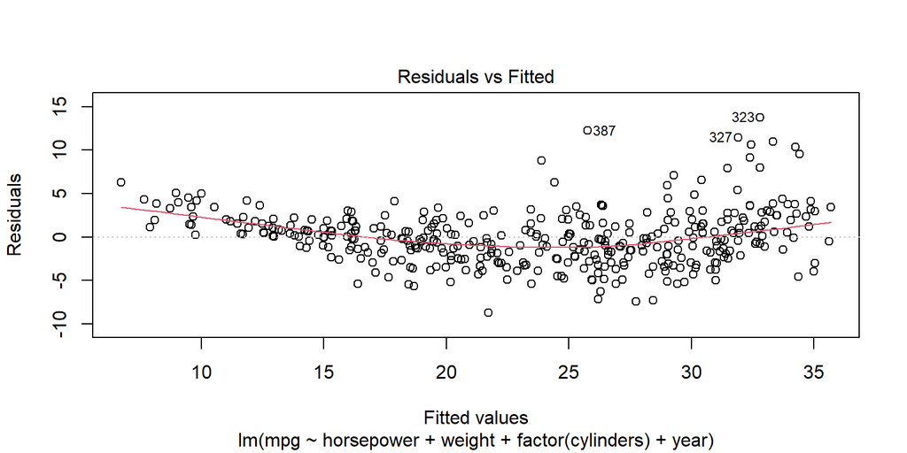

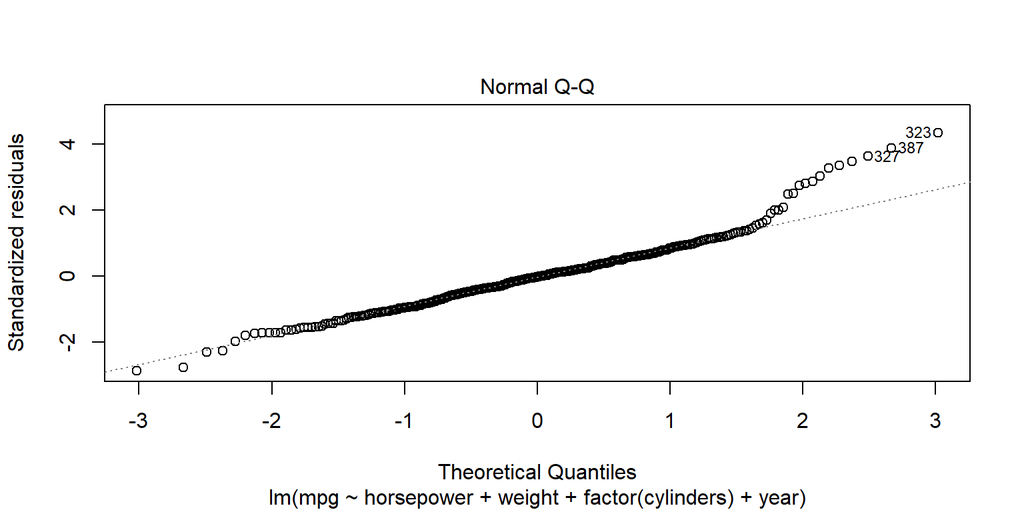

```
##    1    1
## 13.6 26.4
```